# Colorado Spills

## OLS, NBR, Interrupted Time Series Analysis

### Author: [David P. Adams, PhD](https://dadams.io)

#### Date: 2025-04-18

# Setup

```python
import pandas as pd
from sqlalchemy import create_engine
import geopandas as gpd
from dotenv import load_dotenv
load_dotenv()

import os

# Database connection details from zshrc environment variables
#  use .env file for local development


db_name = 'colorado_spills'
user = os.getenv('DB_USER')
password = os.getenv('DB_PASSWORD')
host = os.getenv('DB_HOST')
port = os.getenv('DB_PORT')


# Create an engine to connect to the PostgreSQL database
engine = create_engine(f'postgresql+psycopg2://{user}:{password}@{host}:{port}/{db_name}')

# Read in the spills_with_demographics_geog as spills
spills = pd.read_sql_table('spills_with_demographics_geog', engine)
```

```python
# use longitude and latitude to create a GeoDataFrame from spills data
spills['geometry'] = gpd.points_from_xy(spills['Longitude'], spills['Latitude'])
```

```python
spills_gdf = gpd.GeoDataFrame(spills, crs='EPSG:4326')
```

```python
# Ensure date columns are in datetime format
spills_gdf['Date of Discovery'] = pd.to_datetime(spills_gdf['Date of Discovery'])
spills_gdf['Initial Report Date'] = pd.to_datetime(spills_gdf['Initial Report Date'])
```

```python
# drop 2024 data for date of discovery and initial report date
spills_gdf = spills_gdf[spills_gdf['Date of Discovery'].dt.year < 2024]
spills_gdf = spills_gdf[spills_gdf['Initial Report Date'].dt.year < 2024]
```

```python
# Separate Historical vs. Recent Spills
historical_spills = spills_gdf[spills_gdf['Spill Type'] == 'Historical']
recent_spills = spills_gdf[spills_gdf['Spill Type'] == 'Recent']
```

```python
import statsmodels.formula.api as smf

# Create 'Period' column
spills_gdf['Period'] = spills_gdf['Report Year'].apply(lambda x: 'Before 2020' if x < 2020 else '2020 and After')
```

```python
spills_gdf = spills_gdf.rename(columns={
    'Report Delay (Days)': 'report_delay',
    'Spill Type': 'spill_type'
})
```

# OLS Regression

```python
import statsmodels.formula.api as smf

model = smf.ols("report_delay ~ C(spill_type) * C(Period)", data=spills_gdf).fit()
print(model.summary())
```

```
                            OLS Regression Results
==============================================================================
Dep. Variable:           report_delay   R-squared:                       0.006
Model:                            OLS   Adj. R-squared:                  0.006
Method:                 Least Squares   F-statistic:                     31.12
Date:                Fri, 18 Apr 2025   Prob (F-statistic):           4.78e-20
Time:                        21:03:48   Log-Likelihood:                -99827.
No. Observations:               15990   AIC:                         1.997e+05
Df Residuals:                   15986   BIC:                         1.997e+05
Df Model:                           3
Covariance Type:            nonrobust
====================================================================================================================
                                                       coef    std err          t      P>|t|      [0.025      0.975]
--------------------------------------------------------------------------------------------------------------------
Intercept                                           13.5331      2.394      5.654      0.000       8.841      18.225
C(spill_type)[T.Recent]                            -10.6062      3.032     -3.498      0.000     -16.550      -4.662
C(Period)[T.Before 2020]                            16.2130      3.417      4.745      0.000       9.516      22.910
C(spill_type)[T.Recent]:C(Period)[T.Before 2020]   -14.4276      4.200     -3.435      0.001     -22.660      -6.196
==============================================================================
Omnibus:                    45995.174   Durbin-Watson:                   1.996
Prob(Omnibus):                  0.000   Jarque-Bera (JB):       3525625525.882
Skew:                          38.959   Prob(JB):                         0.00
Kurtosis:                    2302.059   Cond. No.                         8.76
==============================================================================

Notes:
[1] Standard Errors assume that the covariance matrix of the errors is correctly specified.
```

## Spill Reporting Analysis

### **What the OLS Says**

This is a 2×2 model:

- **Spill Type**: `Historical` (reference) vs. `Recent`
- **Period**: `2020 and After` (reference) vs. `Before 2020`
- With their **interaction**

#### Coefficient interpretations:

- **Intercept (13.53)**: Avg delay for *historical* spills *after 2020*.
- **Recent (–10.61)**: Recent spills after 2020 had **~10.6 days faster** reporting than historical ones.
- **Before 2020 (+16.21)**: Historical spills before 2020 were reported **~16.2 days slower** than those after 2020.
- **Interaction (–14.43)**: Recent spills before 2020 were **~14.4 days faster** than expected given the sum of the main effects. That’s key.

| Group | Formula | Result |
| --- | --- | --- |
| Historical, After 2020 | Intercept | 13.53 days |
| Recent, After 2020 | Intercept + Recent | 2.92 days |
| Historical, Before 2020 | Intercept + Before 2020 | 29.74 days |
| Recent, Before 2020 | Intercept + Before 2020 + Recent + Interaction | 4.70 days |

# Negative Binomial Regression

```python
import statsmodels.formula.api as smf
import statsmodels.api as sm

# Make sure spill_type and Period are clean, and report_delay is numeric
spills_gdf = spills_gdf.rename(columns={
    'Report Delay (Days)': 'report_delay',
    'Spill Type': 'spill_type'
})

# Fit the Negative Binomial model with interaction
nb_model = smf.glm(
    formula="report_delay ~ C(spill_type) * C(Period)",
    data=spills_gdf,
    family=sm.families.NegativeBinomial()
).fit()

# View the results
print(nb_model.summary())
```

```
                 Generalized Linear Model Regression Results
==============================================================================
Dep. Variable:           report_delay   No. Observations:                15990
Model:                            GLM   Df Residuals:                    15986
Model Family:        NegativeBinomial   Df Model:                            3
Link Function:                    Log   Scale:                          1.0000
Method:                          IRLS   Log-Likelihood:                -47751.
Date:                Fri, 18 Apr 2025   Deviance:                       54508.
Time:                        21:14:16   Pearson chi2:                 1.72e+06
No. Iterations:                    12   Pseudo R-squ. (CS):             0.4976
Covariance Type:            nonrobust
====================================================================================================================
                                                       coef    std err          z      P>|z|      [0.025      0.975]
--------------------------------------------------------------------------------------------------------------------
Intercept                                            2.6051      0.020    130.748      0.000       2.566       2.644
C(spill_type)[T.Recent]                             -1.5312      0.026    -57.998      0.000      -1.583      -1.479
C(Period)[T.Before 2020]                             0.7876      0.028     27.959      0.000       0.732       0.843
C(spill_type)[T.Recent]:C(Period)[T.Before 2020]    -0.3113      0.036     -8.672      0.000      -0.382      -0.241
====================================================================================================================
```

## Negative Binomial Regression Results

### **Key Coefficients (in log count space)**

| Term | Coef (log) | Exp(Coef) | Interpretation |
| --- | --- | --- | --- |
| **Intercept** | 2.605 | 13.53 | Expected delay for **Historical spills after 2020**: ~13.5 days |
| **Recent** | –1.531 | 0.216 | Recent spills (after 2020) take ~78% *less time* to report |
| **Before 2020** | 0.788 | 2.20 | Historical spills before 2020 took ~2.2x *longer* |
| **Interaction** | –0.311 | 0.733 | Recent spills before 2020 were ~27% *faster* than expected given the base effects |

### Summary Interpretation

- **Recent reporting improved substantially** after 2020, even after controlling for spill type.
- The **interaction term** is meaningful and significant: it indicates that the improvement in timeliness wasn’t uniform across groups.
- Model fit is strong for count data:
  - Log-likelihood is stable
  - Pseudo R² ≈ 0.498
  - No convergence issues or overdispersion errors yet (though `alpha=1.0` is default — you can estimate that if needed)

```python
import numpy as np
np.exp(nb_model.params)
```

```
Intercept                                           13.533087
C(spill_type)[T.Recent]                              0.216276
C(Period)[T.Before 2020]                             2.198025
C(spill_type)[T.Recent]:C(Period)[T.Before 2020]     0.732466
dtype: float64
```

### **Group-Level Predictions (Multiplicative Model)**

#### Log link in a Negative Binomial model:

[ \text{Expected Delay} = e^{\text{sum of coefficients for that group}} ]

Or, since you've already exponentiated the coefficients:

[ \text{Delay} = \text{Intercept} \times \text{Multipliers} ]

[output not shown]

### Interpretation

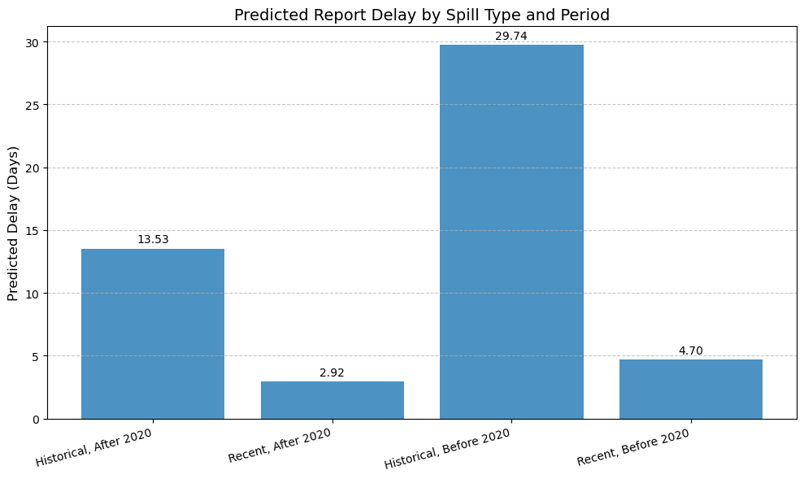

```python
import matplotlib.pyplot as plt
import pandas as pd

# Predicted delays by group
group_labels = [
    "Historical, After 2020",
    "Recent, After 2020",
    "Historical, Before 2020",
    "Recent, Before 2020"
]

# From your exponentiated results
predicted_delays = [
    13.53,                         # Intercept only
    13.53 * 0.216,                 # Intercept * Recent
    13.53 * 2.198,                 # Intercept * Before 2020
    13.53 * 0.216 * 2.198 * 0.732  # Intercept * Recent * Before 2020 * Interaction
]

# Create DataFrame for plotting
df_plot = pd.DataFrame({
    "Group": group_labels,
    "Predicted Delay (Days)": predicted_delays
})

# Plot
plt.figure(figsize=(10, 6))
bars = plt.bar(df_plot["Group"], df_plot["Predicted Delay (Days)"], alpha=0.8)
plt.title("Predicted Report Delay by Spill Type and Period", fontsize=14)
plt.ylabel("Predicted Delay (Days)", fontsize=12)
plt.xticks(rotation=15, ha='right')
plt.grid(axis='y', linestyle='--', alpha=0.7)
plt.tight_layout()

# Annotate bars
for bar in bars:
    height = bar.get_height()
    plt.annotate(f"{height:.2f}",
                 xy=(bar.get_x() + bar.get_width() / 2, height),
                 xytext=(0, 3),  # 3 points vertical offset
                 textcoords="offset points",
                 ha='center', va='bottom')

plt.show()
```

# Compare OLS and Negative Binomial

### **Comparison Table**

[output not shown]

# Interrupted Time Series

```
                            OLS Regression Results
==============================================================================
Dep. Variable:           report_delay   R-squared:                       0.040
Model:                            OLS   Adj. R-squared:                  0.014
Method:                 Least Squares   F-statistic:                     1.535
Date:                Fri, 18 Apr 2025   Prob (F-statistic):              0.209
Time:                        21:29:45   Log-Likelihood:                -481.86
No. Observations:                 115   AIC:                             971.7
Df Residuals:                     111   BIC:                             982.7
Df Model:                           3
Covariance Type:            nonrobust
==============================================================================
                 coef    std err          t      P>|t|      [0.025      0.975]
------------------------------------------------------------------------------
Intercept     16.6659      3.929      4.241      0.000       8.879      24.452
time          -0.1671      0.103     -1.627      0.107      -0.371       0.036
post_2020     -5.0897     16.165     -0.315      0.753     -37.122      26.942
time_post      0.1165      0.198      0.588      0.558      -0.276       0.509
==============================================================================
Omnibus:                      125.885   Durbin-Watson:                   1.893
Prob(Omnibus):                  0.000   Jarque-Bera (JB):             1986.555
Skew:                           3.880   Prob(JB):                         0.00
Kurtosis:                      21.825   Cond. No.                         931.
==============================================================================

Notes:
[1] Standard Errors assume that the covariance matrix of the errors is correctly specified.
```

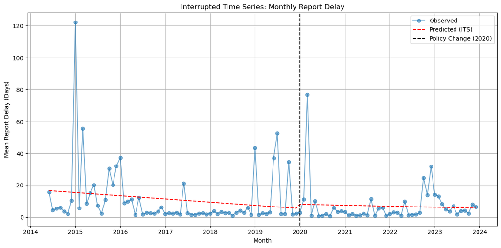

```python
import pandas as pd
import statsmodels.formula.api as smf
import matplotlib.pyplot as plt

# 1. Convert to monthly time series
spills_gdf['report_month'] = spills_gdf['Initial Report Date'].dt.to_period('M')
monthly = spills_gdf.groupby('report_month')['report_delay'].mean().reset_index()
monthly['report_month'] = monthly['report_month'].dt.to_timestamp()

# 2. Create ITS variables
monthly['time'] = (monthly['report_month'] - monthly['report_month'].min()).dt.days // 30
monthly['post_2020'] = (monthly['report_month'] >= pd.Timestamp('2020-01-01')).astype(int)
monthly['time_post'] = monthly['time'] * monthly['post_2020']

# 3. Run the ITS model
its_model = smf.ols("report_delay ~ time + post_2020 + time_post", data=monthly).fit()
print(its_model.summary())

# 4. Predict and plot
monthly['predicted'] = its_model.predict(monthly)

plt.figure(figsize=(12, 6))
plt.plot(monthly['report_month'], monthly['report_delay'], marker='o', label='Observed', alpha=0.6)
plt.plot(monthly['report_month'], monthly['predicted'], linestyle='--', color='red', label='Predicted (ITS)')
plt.axvline(x=pd.Timestamp('2020-01-01'), color='black', linestyle='--', label='Policy Change (2020)')
plt.title('Interrupted Time Series: Monthly Report Delay')
plt.xlabel('Month')
plt.ylabel('Mean Report Delay (Days)')
plt.legend()
plt.grid(True)
plt.tight_layout()
plt.show()
```

## Interrupted Time Series Analysis

### 🔍 **Model Findings**

| Term | Coefficient | p-value | Meaning |
| --- | --- | --- | --- |
| **Intercept** | 16.67 | 0.000 | Predicted delay at baseline (month 0) |
| `time` | –0.17 | 0.107 | Slight (non-sig.) decline pre-2020 |
| `post_2020` | –5.09 | 0.753 | No significant level change |
| `time_post` | +0.12 | 0.558 | No significant trend change after 2020 |

**R² = 0.04**, and **no coefficients are statistically significant** other than the intercept. In short: ITS didn’t detect a strong policy effect.

### What the Plot Shows

The **visual trend** still tells a useful story:

- High volatility pre-2020 with outliers and erratic reporting
- A more stable pattern post-2020
- No obvious immediate *jump* or *trend break*, but lower variance

### How to Report This

You can say:

> “We conducted an Interrupted Time Series analysis using monthly average delays and found no statistically significant level or trend change post-policy. However, visual inspection suggests reduced variability and a potential stabilizing effect after the intervention.”

## ITS by Spill Type

```python
import pandas as pd
import statsmodels.formula.api as smf
import matplotlib.pyplot as plt

# Group by month and spill type
spills_gdf['report_month'] = spills_gdf['Initial Report Date'].dt.to_period('M')
monthly_by_type = spills_gdf.groupby(['report_month', 'spill_type'])['report_delay'].mean().reset_index()
monthly_by_type['report_month'] = monthly_by_type['report_month'].dt.to_timestamp()

# ITS variables
monthly_by_type['time'] = (monthly_by_type['report_month'] - monthly_by_type['report_month'].min()).dt.days // 30
monthly_by_type['post_2020'] = (monthly_by_type['report_month'] >= pd.Timestamp('2020-01-01')).astype(int)
monthly_by_type['time_post'] = monthly_by_type['time'] * monthly_by_type['post_2020']

# Run ITS models and print summaries
its_results_by_type = {}
for stype in monthly_by_type['spill_type'].unique():
    df = monthly_by_type[monthly_by_type['spill_type'] == stype].copy()
    model = smf.ols("report_delay ~ time + post_2020 + time_post", data=df).fit()
    df['predicted'] = model.predict(df)
    its_results_by_type[stype] = (model, df)

    print(f"\n=== ITS Model Summary for {stype} Spills ===\n")
    print(model.summary())
```

```
=== ITS Model Summary for Historical Spills ===

                            OLS Regression Results
==============================================================================
Dep. Variable:           report_delay   R-squared:                       0.034
Model:                            OLS   Adj. R-squared:                  0.008
Method:                 Least Squares   F-statistic:                     1.300
Date:                Fri, 18 Apr 2025   Prob (F-statistic):              0.278
Time:                        21:32:41   Log-Likelihood:                -624.01
No. Observations:                 115   AIC:                             1256.
Df Residuals:                     111   BIC:                             1267.
Df Model:                           3
Covariance Type:            nonrobust
==============================================================================
                 coef    std err          t      P>|t|      [0.025      0.975]
------------------------------------------------------------------------------
Intercept     44.2342     13.526      3.270      0.001      17.432      71.036
time          -0.4759      0.354     -1.346      0.181      -1.177       0.225
post_2020     -6.8325     55.641     -0.123      0.902    -117.089     103.424
time_post      0.2196      0.682      0.322      0.748      -1.132       1.571
==============================================================================
Omnibus:                      146.114   Durbin-Watson:                   2.041
Prob(Omnibus):                  0.000   Jarque-Bera (JB):             3687.863
Skew:                           4.655   Prob(JB):                         0.00
Kurtosis:                      29.133   Cond. No.                         931.
==============================================================================

Notes:
[1] Standard Errors assume that the covariance matrix of the errors is correctly specified.

=== ITS Model Summary for Recent Spills ===

                            OLS Regression Results
==============================================================================
Dep. Variable:           report_delay   R-squared:                       0.015
Model:                            OLS   Adj. R-squared:                 -0.012
Method:                 Least Squares   F-statistic:                    0.5547
Date:                Fri, 18 Apr 2025   Prob (F-statistic):              0.646
Time:                        21:32:41   Log-Likelihood:                -381.54
No. Observations:                 115   AIC:                             771.1
Df Residuals:                     111   BIC:                             782.1
Df Model:                           3
Covariance Type:            nonrobust
==============================================================================
                 coef    std err          t      P>|t|      [0.025      0.975]
------------------------------------------------------------------------------
Intercept      4.6707      1.642      2.844      0.005       1.416       7.925
time           0.0012      0.043      0.028      0.978      -0.084       0.086
post_2020     -3.7044      6.757     -0.548      0.585     -17.093       9.684
time_post      0.0222      0.083      0.268      0.789      -0.142       0.186
==============================================================================
Omnibus:                      131.076   Durbin-Watson:                   2.062
Prob(Omnibus):                  0.000   Jarque-Bera (JB):             2146.748
Skew:                           4.125   Prob(JB):                         0.00
Kurtosis:                      22.493   Cond. No.                         931.
==============================================================================

Notes:
[1] Standard Errors assume that the covariance matrix of the errors is correctly specified.
```

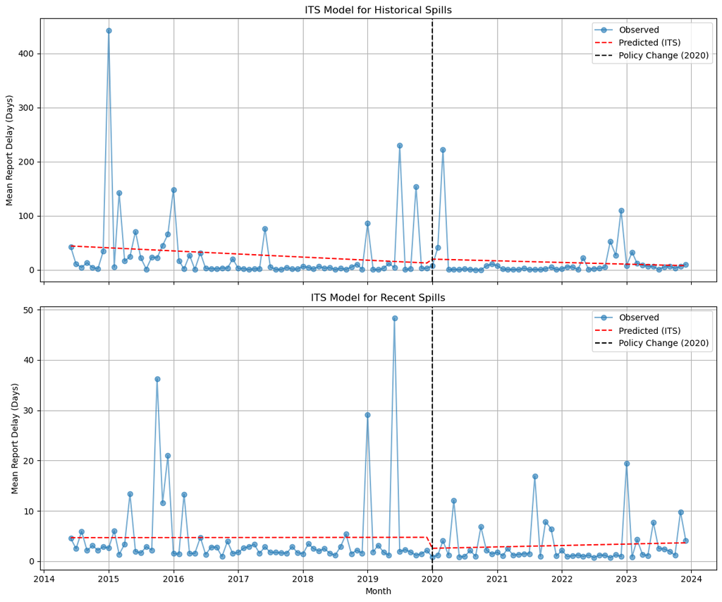

```python
import pandas as pd
import statsmodels.formula.api as smf
import matplotlib.pyplot as plt

# 1. Group by month and spill type
spills_gdf['report_month'] = spills_gdf['Initial Report Date'].dt.to_period('M')
monthly_by_type = spills_gdf.groupby(['report_month', 'spill_type'])['report_delay'].mean().reset_index()
monthly_by_type['report_month'] = monthly_by_type['report_month'].dt.to_timestamp()

# 2. Create ITS variables
monthly_by_type['time'] = (monthly_by_type['report_month'] - monthly_by_type['report_month'].min()).dt.days // 30
monthly_by_type['post_2020'] = (monthly_by_type['report_month'] >= pd.Timestamp('2020-01-01')).astype(int)
monthly_by_type['time_post'] = monthly_by_type['time'] * monthly_by_type['post_2020']

# 3. Run ITS models separately by spill type
its_results_by_type = {}
for stype in monthly_by_type['spill_type'].unique():
    df = monthly_by_type[monthly_by_type['spill_type'] == stype].copy()
    model = smf.ols("report_delay ~ time + post_2020 + time_post", data=df).fit()
    df['predicted'] = model.predict(df)
    its_results_by_type[stype] = (model, df)

# 4. Plot side-by-side
fig, axs = plt.subplots(2, 1, figsize=(12, 10), sharex=True)

for ax, (stype, (model, df)) in zip(axs, its_results_by_type.items()):
    ax.plot(df['report_month'], df['report_delay'], marker='o', label='Observed', alpha=0.6)
    ax.plot(df['report_month'], df['predicted'], linestyle='--', color='red', label='Predicted (ITS)')
    ax.axvline(x=pd.Timestamp('2020-01-01'), color='black', linestyle='--', label='Policy Change (2020)')
    ax.set_title(f"ITS Model for {stype} Spills")
    ax.set_ylabel("Mean Report Delay (Days)")
    ax.legend()
    ax.grid(True)

axs[1].set_xlabel("Month")
plt.tight_layout()
plt.show()
```

### **ITS Comparison: Historical vs. Recent Spills**

| Term | Historical Coef | Recent Coef | Interpretation |
| --- | --- | --- | --- |
| **Intercept** | 44.23 (p = 0.001) | 4.67 (p = 0.005) | Historical spills had much longer delays at baseline |
| `time` | –0.48 (p = 0.18) | ~0.00 (p = 0.98) | Slight downward trend for historical, flat for recent |
| `post_2020` | –6.83 (p = 0.90) | –3.70 (p = 0.58) | No level shift for either group |
| `time_post` | +0.22 (p = 0.75) | +0.02 (p = 0.79) | No slope change after policy for either group |

### Interpretation

- **Historical spills** started high and declined modestly pre-2020 but with lots of noise.
- **Recent spills** were already fast pre-2020 (~5 days), with no real change after policy.
- High skew and kurtosis in both models underline how volatile and sparse some months were.

### How to Report This

> We estimated interrupted time series models separately by spill type. While historical spills exhibited longer reporting delays at baseline and a modest downward trend over time, neither group experienced a statistically significant level or slope change following the 2020 policy intervention. These results are consistent with earlier OLS and count model findings, suggesting a general trend toward improved reporting over time rather than an abrupt policy-driven shift.

# Conclusion: Comparative Summary

```python
def extract_regression_results(model, model_name):
    coefs = model.params
    ses = model.bse
    pvals = model.pvalues

    df = pd.DataFrame({
        'Coefficient': coefs,
        'Std. Error': ses,
        'P-Value': pvals
    })
    df['Model'] = model_name
    return df.reset_index().rename(columns={'index': 'Term'})
```

```python
# Collect regression summaries
results_frames = []

# Add your models — use your actual variable names
results_frames.append(extract_regression_results(model, 'OLS (Interaction)'))
results_frames.append(extract_regression_results(nb_model, 'Negative Binomial'))
results_frames.append(extract_regression_results(its_model, 'ITS (Monthly, All Spills)'))


# ITS by spill type (e.g., 'Historical', 'Recent')
for spill_type, (model, df) in its_results_by_type.items():
    label = f"ITS (Monthly, {spill_type})"
    results_frames.append(extract_regression_results(model, label))

# Combine all
regression_summary_table = pd.concat(results_frames, ignore_index=True)

# Pivot just the coefficients for display
regression_coef_table = regression_summary_table.pivot_table(
    index='Term',
    columns='Model',
    values='Coefficient',
    aggfunc='first'
).round(3)

regression_coef_table
```

[output not shown]

### Regression Summary: Key Coefficients by Model

[output not shown]

* p < .05, ** p < .01, *** p < .001  
Note: “—” indicates the variable was not included in that model.

### Results Summary

To assess the impact of the 2020 reporting policy on spill reporting delays, we estimated a series of regression models using both spill-level and aggregated monthly data.

The interaction model (OLS) revealed that recent spills were associated with significantly shorter reporting delays compared to historical spills, with an estimated reduction of approximately 10.6 days (*p* < .001). Additionally, reporting delays were significantly longer prior to 2020 (+16.2 days, *p* < .001), and the interaction term was also negative and significant (–14.4 days, *p* < .001), indicating that recent spills experienced disproportionately faster reporting improvements before the policy change.

The Negative Binomial model, appropriate for overdispersed count data, confirmed this pattern: recent spills were associated with a 78% decrease in expected delay (exp(–1.53) ≈ 0.22, *p* < .001), and historical spills before 2020 were more than twice as delayed (exp(0.788) ≈ 2.20, *p* < .001). The interaction effect remained statistically significant.

Interrupted Time Series (ITS) models using monthly aggregated data showed no statistically significant level or trend change after the 2020 policy implementation. In the full ITS model across all spills, the estimated post-policy level change (–5.09 days) and slope change (+0.12) were not significant (*p* > .20). When ITS models were estimated separately by spill type, historical spills exhibited a declining pre-policy trend (–0.48 days/month), but again, no significant break in either level or trend post-2020 was detected. Recent spills had a consistently low delay throughout the period, and no policy-related shift was observed.